# Preterm Exercise

Carole Voulgaris

2022-08-16

## Introduction

The purpose of this RMarkdown file is demonstrate some introductory tidyverse skills.

Prior to running any of this code, you should start a new RStudio project.

Download the following from from Canvas (Pre-Term Workshop > R exercise): * This file (example-rmd.Rmd) * FY2022_cambridge_asssessor.csv * cambridge_parcels.geojson

Save all three files to the project directory associated with the RStudio project you just created. Open the RStudio project (not just the script).

## Required packages

This exercise uses the following packages:

```r
library(tidyverse)
library(sf)
library(here)
```

## Load data

### Load data from a csv file

The following code will read in data from a csv file.

```r
parcel_data <- here("FY2022_cambridge_assessor.csv") %>%
  read_csv()
```

The `here()` function will create a path to csv file in your project directory. The pipe (`%>%`) at the end of that line will take that path and enter it as the first argument of the `read_csv()` function on the next line. The `read_csv()` function is aptly named. It reads a csv file and saves the contents to a tibble you’ve named at the start of this piped set of functions (`parcel_data`)

### Load data from a geojson file

To load data from a file format associated with spatial data, use `st_read()` instead of `read_csv()`.

```r
parcel_boundaries <- here("cambridge_parcels.geojson") %>%
  st_read()
```

## Join two datasets

The `left_join()` function will combine the two tibbles based on a common variable (in this case, gisid), keeping (and possibly repeating) rows in the “left” tibble (the one you mention first) and dropping any rows from the “right” tibble that aren’t present in the the left one.

```r
parcel_boundaries_data <- parcel_boundaries %>%
  left_join(parcel_data)
```

## Select columns

The `select()` function lets you select the columns you want to keep.

```r
owners_values <- parcel_boundaries_data %>%
  select(gisid, landarea, buildingvalue, landvalue, owner_name)
```

## Filter rows

Maybe we only want to analyze the properties owned by Harvard. We can filter for these.

```r
Harvard_parcels <- owners_values %>%
  filter(owner_name == "PRESIDENT & FELLOWS OF HARVARD COLLEGE")
```

And we can filter further to remove duplicates.

```r
Harvard_unique <- Harvard_parcels %>%
  filter(!duplicated(.))
```

## Calculate a new variable

The mutate function will create a new variable. With math.

```r
# Calculate a new variable
Harvard_pct_value <- Harvard_unique %>%
  mutate(pct_bldg = buildingvalue / (buildingvalue + landvalue))
```

## Better living with pipes

We can actually combine all of the above into one long piped set of functions, so save us from having to clutter up our environment with all those intermediate tibbles.

```r
final_data <- parcel_boundaries %>%
  left_join(parcel_data) %>%
  select(gisid, landarea, buildingvalue, landvalue, owner_name) %>%
  filter(owner_name == "PRESIDENT & FELLOWS OF HARVARD COLLEGE") %>%
  filter(!duplicated(.)) %>%
  mutate(pct_bldg = buildingvalue / (buildingvalue + landvalue))
```

## Plot some data

### Scatter plot

We can use ggplot to create a scatterplot of our data.

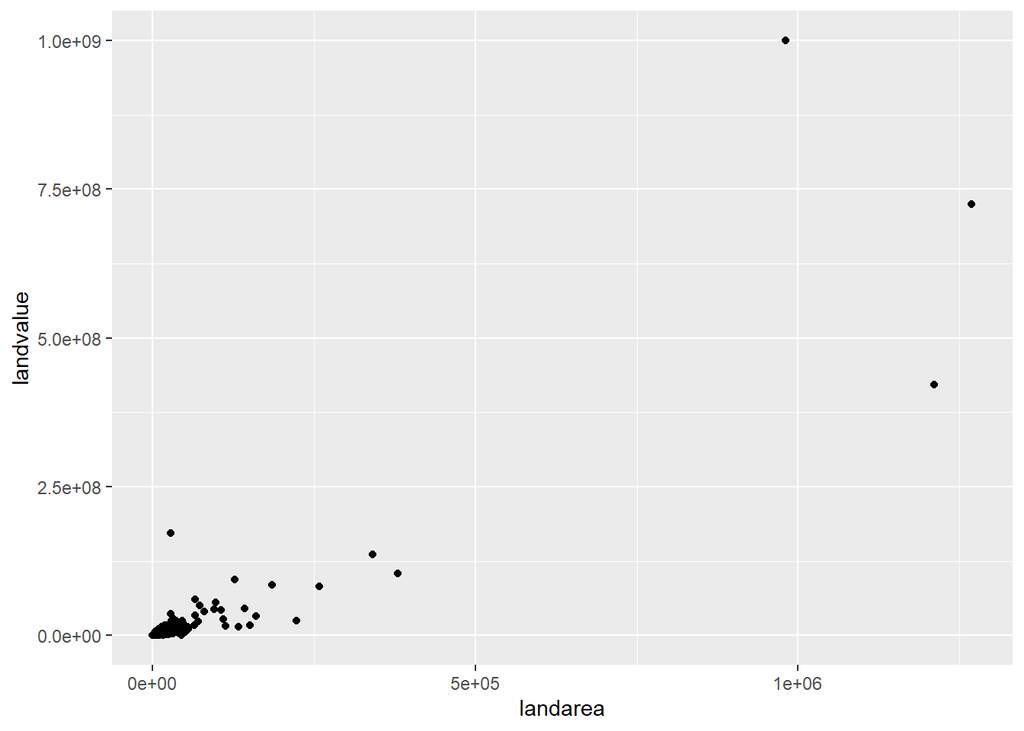

```r
scatter <- ggplot(final_data) +
  geom_point(aes(x = landarea, y = landvalue))

scatter
```

I’m trying to keep this all super simple, but I can’t help myself These data are begging to be log-transformed.

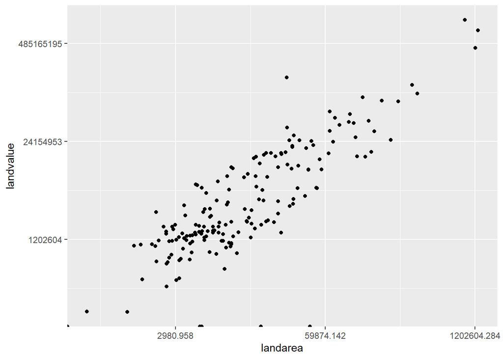

```r
scatter_log <- scatter +
  scale_x_continuous(trans = "log") +
  scale_y_continuous(trans = "log")

scatter_log
```

### Map

We can also use ggplot to create a map.

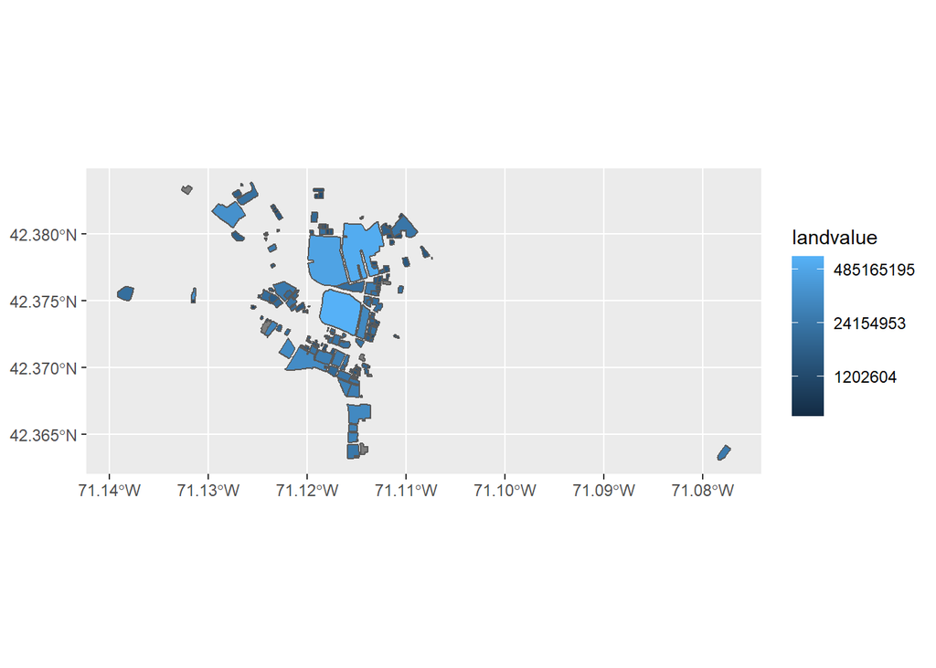

```r
map <- ggplot(final_data) +
  geom_sf(aes(fill = landvalue)) +
  scale_fill_continuous(trans = "log")

map
```

## Save some files

### Datasets

You can save your dataset as a csv.

```r
write_csv(final_data, "harvard_parcels.csv")
```

Or as a geojson.

```r
st_write(final_data, "harvard_parcels.geojson")
```

```
## Writing layer `harvard_parcels' to data source
##   `harvard_parcels.geojson' using driver `GeoJSON'
## Writing 189 features with 6 fields and geometry type Multi Polygon.
```

### Plots

You can also use `ggsave()` to save plots in a variety of different image formats (including PDFs).

```r
ggsave("scatter.pdf", plot = scatter_log)
ggsave("map.png", plot = map)
```